# Chilly Bees: How Do Physiological Traits in Female Carpenter Bees Determine Climate Resistance?

Nathalie Bonnet

2023-17-03

## Abstract

Understanding the relationship between physiological factors on social behavior in bees is critical to understanding their ecological dynamics. This study investigates the relationship between body mass, ovary size, Dufour’s gland size, and chill coma recovery time in female Xylocopa tabaniformis bees. Analyses reveal a significant predictive relationship between bee body mass and both ovariole length and Dufour’s gland length, indicating physiological response influences beyond social behavior. Body mass does not emerge as a significant predictor of CCRT, suggesting other factors as better predictors for thermal tolerance. Conflicting conclusions arise regarding CCRT as a function of physical trauma or age, emphasizing a need for further investigation. Future research should expand the scope of species studied. The findings of this study provide insight into the physiological underpinnings of bee sociality and highlight the complexity of bee ecological dynamics.

## Introduction

The sociality of bees is not a well-understood phenomenon, as social behaviors range from solitary to eusocial with a high degree of interspecies variability (Wcislo and Fewell, 2017). Social behavior is likely influenced by a gamut of environmental, chemical, and physiological factors, and many gaps exist in the understanding of the interplay of these variables. It is critical to broaden scientific understanding of these characteristics as they relate to the resilience of bee species in a rapidly changing climate.

The family of bees known as Apidae has been categorized as semi-social to eusocial, meaning they sometimes display generational overlap and labor division (Wcislo and Fewell, 2017). Xylocopa tabaniformis is a species of American Carpenter bee from the family Apidae that displays facultatively social behavior. The social behavior in these bees is thought to be a function of chemical signaling from several identified exocrine glands, one of which being the Dufour’s gland in female Carpenter bees (Gerling et al., 1989). Chemical analyses show that compounds from the Dufour’s gland are strongly associated with ovary size. Ovary size is thought to indicate sociality, with larger ovary size hypothesized to be associated with my dominant or “queen-like” behaviors. Further, the presence of yellow bodies in ovaries is indicative of reabsorbed oocytes and previous reproductive activity (Saleh et al., 2023).

To collect data about the chemical composition of Dufour’s glands in association with other physical characteristics, 33 female Carpenter bees were sampled from the UCSB area by Madeleine Ostwald in collaboration with the Cheadle Center for Biodiversity and Ecological Restoration. Out of these bees, 26 were tested for the time to recover from cold exposure (chill coma recovery time or CCRT). This measurement provides a possible metric for the geographic distribution of the species according to their thermal tolerance (Oyen et al., 2021). The mass of each individual was also recorded, and dissections of each bee were performed to measure the length and width of the Dufour’s gland and the length of the 2 largest ovarioles of each individual. The presence of yellow bodies in the ovaries was also noted. Chemical extraction was performed on the Dufour’s gland for future chemical analysis in collaboration with Nicholas Saleh at Fresno Pacific University to give insight into the sociality of bees based on their chemical signal. Further, the intertegular distance of each bee was measured along with head width, and wing wear was scored on a scale of 0-5 in ascending order.

Our goal was to investigate the behavioral responses influenced by the physical characteristics of female carpenter bees. I aim to analyze whether CCRT varies by the presence or absence of yellow bodies or wing wear as an indication of physical wear and age, where a longer CCRT indicates less thermal resistance. I also want to investigate whether CCRT is predicted by body mass. Further, I hypothesize that although ovary size is known to be influenced by sociality, it is also a function of body mass, and I aim to determine how well body mass can predict ovary and Dufour’s size.

## Exploratory Data Analysis

The data set collected was cleaned by removing any NAs, which resulted in 26 total observations, and subsetting wing wear data for the right and left wings by sorting bees with scores 0-1 into “undamaged” and 2-5 into “damaged” categories to more easily identify older or more damaged individuals. Removing Nas resulted in there being too few observations of no yellow bodies to perform statistical analyses on CCRT based on yellow body data, so this variable was not included in further statistical tests (Appendix section 1).

No transformations were done on the data, as all numeric data displayed normal distributions according to their histogram, qqplot, and Shapiro Wilks p-values (Appendix section 1). All variables of interest in statistical analysis showed equal variance according to Levene’s test results, and no significant outliers were looking at the residuals vs. leverage plots (Appendix section 2).

The data was plotted to visualize the distribution and meaningful relationships being explored. CCRT data followed a normal/ Gaussian distribution (Fig. 1 and Fig. 2). There appears to be a positive linear relationship between CCRT and bee body mass (Fig. 3), as well as positive linear relationships between mass and Dufour’s length (Fig. 4) and ovariole length (Fig. 5). Visualizing variation of CCRT by wing wear category, Figure 6 indicates that there is a potentially significant difference between undamaged and damaged individuals based on left-wing wear data. Figure 7 indicates less distinguishable differences between categories based on right-wing wear data.

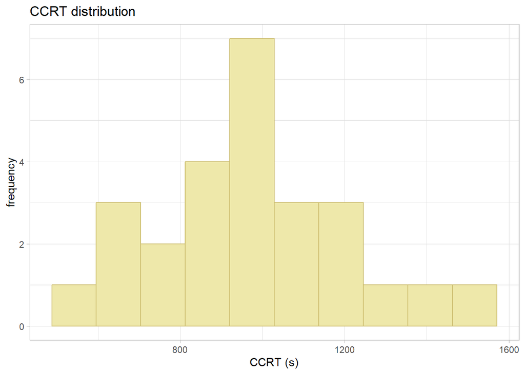

Figure 1: CCRT histogram displays the distribution of chill coma recovery time across individuals, and displays a normal/ Gaussian distribution

```
## [1]  8 16
```

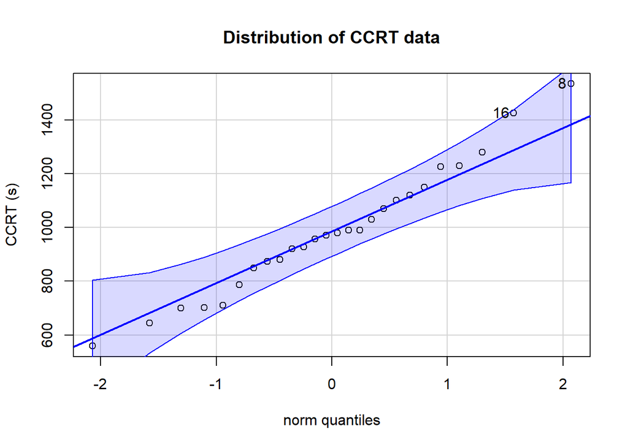

Figure 2: quantile-quantile plot displaying the distribution of CCRT data displaying that data comes from a normal disribution

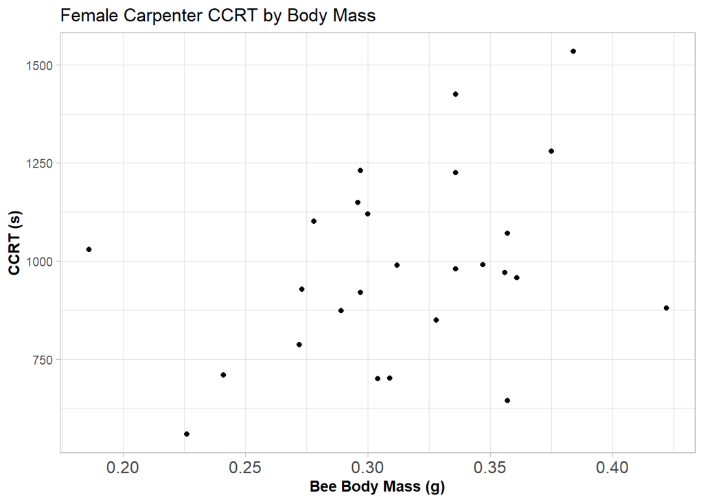

Figure 3: Scatterplot of bee body mass versus CCRT. There appears to be a positive linear relationship with a few potential outliers.

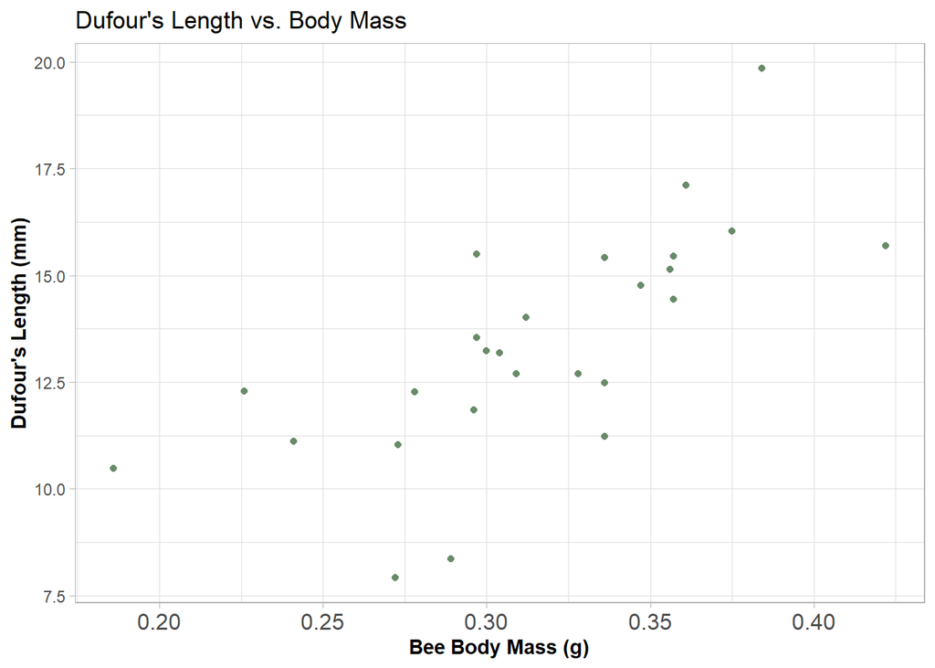

Figure 4: Scatterplot displaying the relationship between bee body mass and Dufour’s length. There appears to be a positive linear relationship.

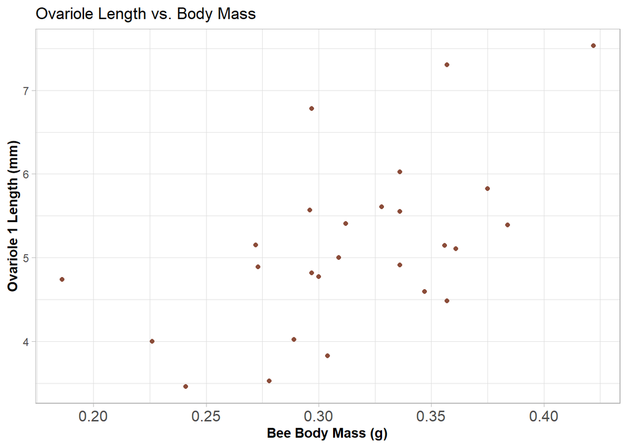

Figure 5: Scatterplot displaying the relationship between body mass and Ovariole length. There appears to be a positive linear relationship.

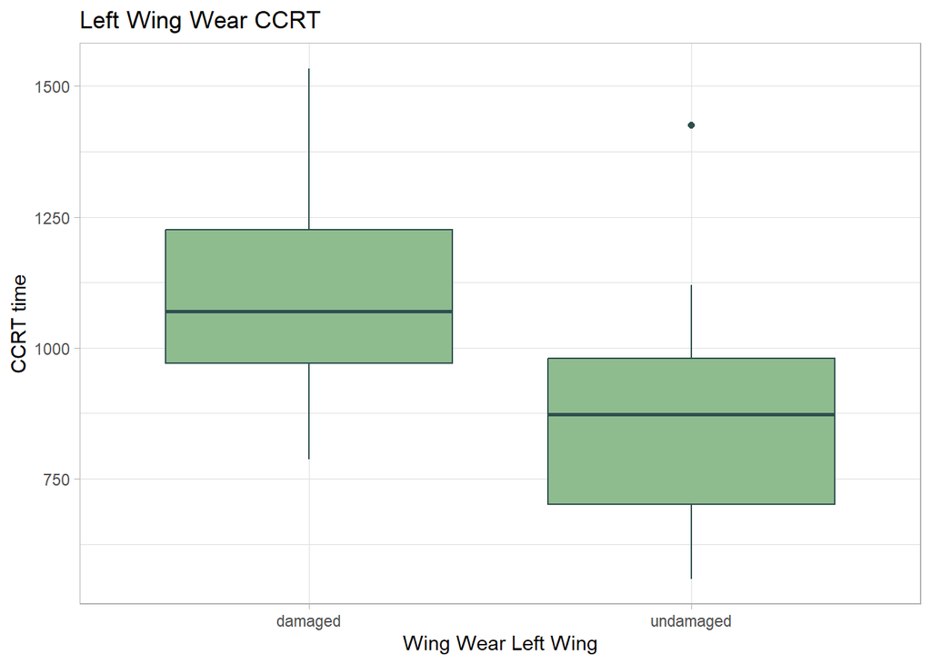

Figure 6: Boxplot displaying CCRT by left wing wear category. There appears to be a difference in the medians, where individuals with damaged wings have a longer median CCRT.

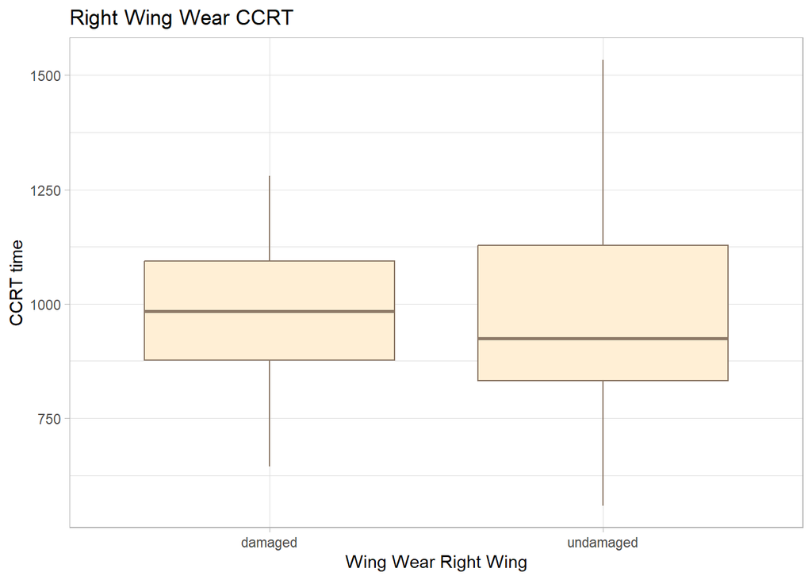

Figure 7: Boxplot displaying CCRT by right wing wear category. There appears to be significant overlap in the range of CCRT measurements, with little difference between median CCRT in damaged and undamaged groups.

## Statistical Methods

Statistical analysis was performed to determine the significance of wing damage on CCRT, a GLM was used to analyze the association between bee body mass and CCRT, and linear models were created to determine if body mass is a significant predictor of ovariole and Dufour’s length. α = 0.05 in all tests.

#### Does CCRT Vary by Wing Damage?

To explore CCRT variation by wing damage, 2 two-sample t-tests were performed on left and right data individually to compare the mean CCRT of damaged vs. undamaged bees in each group. To check the assumptions of a two-sample t, the normality and variance of each group were tested using the Shapiro-Wilks test and Levene’s test. The Shapiro-Wilks p-value was determined to be 0.8742 for both left and right-wing groups, so because p > 0.05, we fail to reject the null hypothesis and determine that the data are normally distributed. Levene’s test for homogeneity of variance yielded a p-value of 0.6817 for the left wing and a p-value = 0.2814 for the right wing. Because both p> 0.05, we fail to reject the null hypothesis and conclude that the variance between categories in both groups is equal (Appendix section 2). Having met the normality and equal variance assumptions, the two-sample t-tests were performed on the left and right groups.

Shapiro Wilks H0: data come from a normal distribution Ha: the data are not normally distributed

Levene’s Test H0: 𝜎²(damaged) = 𝜎²(undamaged) Ha: variance between damaged and undamaged data is not equal

Two-sample T-test H0: μ(damaged) = μ(undamaged) Ha: the means of damaged and undamaged data are not equal

#### Is Body Mass a Good Predictor of CCRT, Ovariole Length, and Dufour’s Gland Length?

To determine the significance of body mass as a predictor of CCRT, a generalized linear model was used. In checking the assumptions of a linear model for CCRT and body mass, a Shapiro-Wilks test was performed on the residuals and yielded a p-value of 0.5904. Based on the p-value > 0.05, we fail to reject the null hypothesis and conclude that the residuals are normally distributed. However, looking at the residuals vs. fitted plot, the variance of the residuals does not appear to be equal based on the heteroscedasticity of the plot (Appendix section 2). Based on this, a GLM was used for a Gaussian distribution. To analyze the relationship between mass and ovariole and Dufour’s, linear models were used. Shapiro-Wilks tests were used on the residuals of each model to check their normality. For the mass vs. ovariole linear model, Shapiro-Wilks p-value = 0.3383. For the mass vs. Dufour’s model, p = 0.4566. Both p-values> 0.05 mean we fail to reject the null hypothesis, so we can conclude that the residuals of both models are normally distributed. The residuals vs. fitted plot for both models displayed equal variance for the residuals. Having met the assumptions for normality and variance of residuals, a linear regression was appropriate for both models.

Generalized linear model: H0: there is no association between bee body mass and CCRT. Ha: there is a significant association between body mass and CCRT.

Linear model: H0: β=0 Body mass is not a significant predictor of ovariole length/ Dufour’s length. Ha: β≠0 Body mass is a significant predictor of ovariole length/ Dufour’s length.

## Results

#### Two Sample T-Test: CCRT by Wing Damage

A statistically significant difference in CCRT mean was found between damaged and undamaged bees based on left wing data. The p-value of 0.0127522 is <0.05, which allows us to reject the null hypothesis that there is no difference between means, and conclude that there is a significant difference between CCRT in damaged and undamaged bees. The mean CCRT for damaged was 1096.077 seconds, and the mean CCRT for undamaged was 873.2308 seconds (Table 1). However, right wing data suggested otherwise. The two sample T-test for right wing yielded a p-value of 0.9856 > 0.05 (Table 2). Based on this test, we fail to reject the null hypothesis and conclude that there is no difference between the mean CCRT between damaged and undamaged bees based on right wing data.

Two Sample T-test Results: CCRT Between Undamaged and Damaged Left Wings

|  | μ damaged | μ undamaged | t | p-value | df | conf.low | conf.high | method | alternative |
| --- | --- | --- | --- | --- | --- | --- | --- | --- | --- |
| 222.8462 | 1096.077 | 873.2308 | 2.691514 | 0.0127522 | 24 | 51.96397 | 393.7283 | Two Sample t-test | two.sided |

Two Sample T-test Results: CCRT Between Undamaged and Damaged Right Wings

|  | μ damaged | μ undamaged | t | p-value | df | conf.low | conf.high | method | alternative |
| --- | --- | --- | --- | --- | --- | --- | --- | --- | --- |
| -1.72619 | 983.8571 | 985.5833 | -0.0182186 | 0.9856151 | 24 | -197.278 | 193.8257 | Two Sample t-test | two.sided |

#### Linear Models: Bee Mass as a Predictor of CCRT and Ovary and Gland Size

The generalized linear model determined that there is not a significant association between mass and CCRT. The p-value from the model was 0.0919, since p > 0.05, we fail to reject the null hypothesis that bee mass is not associated with CCRT, and determine that bee mass is not a good predictor variable of CCRT in female carpenter bees. The linear regression on mass vs ovariole length with a = 0.05 yielded p-value = 0.0023571, and adjusted R-squared = 0.297. Based on p<0.05 and β = 11.26 ≠0, we can reject the null hypothesis and conclude that mass is a significant predictor of ovariole size in female carpenter bees. We can say based on the adjusted R-squared that 29.7% of variation in ovariole size can be explained by variation in bee mass.The linear regression gives the equation y= 1.59 + 11.26xi, indicating that there is a positive linear relationship between mass and ovariole length where as body mass increases, so does ovariole length. The linear regression on mass vs Dufour’s length with a=0.05 yielded p-value = 0.0000662, and adjusted R-squared = 0.4704. Similarly to the ovariole model, p<0.05, and β = 35.66, so we reject the null and conclude that mass is a significant predictor of Dufour’s length in female carpenter bees. 47.04% of variation in Dufour’s length can be predicted by variation in bee mass. This model gives the equation y = 2.16 + 35.66xi, where the positive slope indicates a proportional relationship between mass and Dufour’s length.

Generalized Linear Model Results for Bee Mass vs. CCRT

| Predictor | Estimate SD | SE | t | p-value |
| --- | --- | --- | --- | --- |
| (Intercept) | 500.2032 | 279.5136 | 1.789548 | 0.0861545 |
| Bee.Mass..g. | 1540.7605 | 877.6523 | 1.755548 | 0.0919232 |

Summary of Mass vs. Ovariole Length Linear Model

| Predictor | Estimate SD | SE | t | p-value | Adjusted R² |
| --- | --- | --- | --- | --- | --- |
| (Intercept) | 1.591941 | 1.05462 | 1.509493 | 0.1442269 | NA |
| Bee.Mass..g. | 11.259134 | 3.31143 | 3.400082 | 0.0023571 | 0.297 |

$$y= 1.59 + 11.26xi$$

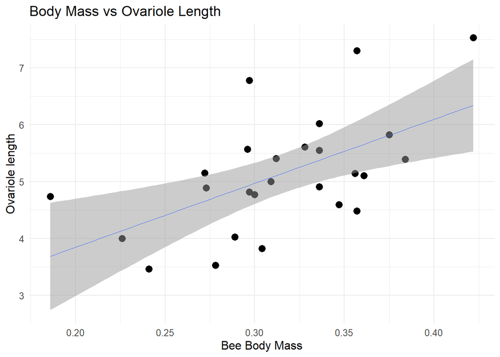

Figure 8: Scatterplot of body mass compared to ovariole length fitted with a 90% confidence interval.

Summary of Mass vs. Dufour’s Gland Length Linear Model

| Predictor | Estimate SD | SE | t | p-value | Adjusted R² |
| --- | --- | --- | --- | --- | --- |
| (Intercept) | 2.164713 | 2.357902 | 0.9180674 | 0.3677183 | NA |
| Bee.Mass..g. | 35.661954 | 7.403639 | 4.8168145 | 0.0000662 | 0.4704 |

$$y = 2.16 + 35.66xi$$

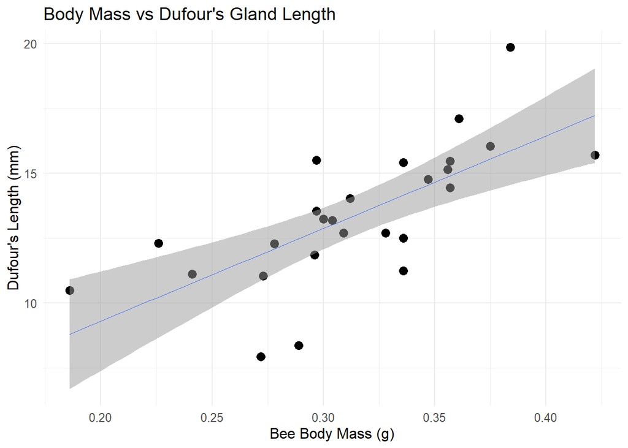

Figure 9: Scatterplot of body mass compared to Dufour’s gland length fitted with a 90% confidence interval.

## Discussion

From these analyses, it is clear that bee body mass is a significant predictor of both ovariole length and Dufour’s gland length. The linear models suggest that a significant amount of variance in both ovary and Dufour’s gland size is explained by variation in mass, and that both have a positive linear relationship with bee mass. These results suggest that although the literature suggests that Dufour’s and ovary size are strongly correlated with social behavior, there are physiological influences associated as well. Mass was not strongly associated as a predictor for CCRT based on the generalized linear model, suggesting that other factors have larger influences on this particular metric. Other hypothesized factors that may play into bee thermal tolerance are the individual’s sex and phenotypic plasticity as a response to different environmental stimuli (Oyen et al., 2021). The results of the two sample t-test determined conflicting conclusions about the variation of CCRT by physical damage over time as determined by the extent of wing wear. Although the left wing data reported that CCRT did vary significantly between damaged and undamaged individuals, the right wing data found no significant difference between groups. Wing wear can be interpreted as a function of wear as a function of age. Based on the results, these factors are potentially significant to thermal tolerance, but further investigation is needed.

There were limitations of this study from the sample size of the cleaned data n=26, and the timing of the study. Although this sample allowed for statistical analyses of many variables, certain variables were not able to be tested or yielded ambiguous results. It would be more informative to collect more samples, however, ecological testing must be balanced with the impact on the communities of interest. This factor of the study meant that the significance of yellow body presence was not able to be tested due to a lack of data from ovaries not containing them. This was very likely because all data was collected in June, at a time when female carpenter bees had already been reproductively active. This facet of sampling suggests that such studies should be replicated throughout the entire period of bee activity to give better insight into the seasonal variation of thermal tolerance.

## References

Gerling, D., Velthuis, H. H., & Hefetz , A. (1989). Bionomics of the large carpenter bees of the genus Xylocopa. Annual Review of Entomology, 34(1), 163–190. https://doi.org/10.1146/annurev.ento.34.1.163

Oyen, K. J., Jardine, L. E., Parsons, Z. M., Herndon, J. D., Strange, J. P., Lozier, J. D., & Dillon, M. E. (2021). Body mass and sex, not local climate, drive differences in chill coma recovery times in common garden reared Bumble Bees. Journal of Comparative Physiology B, 191(5), 843–854. https://doi.org/10.1007/s00360-021-01385-7

Saleh, N. W., Ostwald, M. M., & Ramírez, S. R. (2023). Cuticular and glandular chemistry are correlated with ovary size in two populations of the facultatively social carpenter Bee, Xylocopa Sonorina. BiorXiv. https://doi.org/10.21203/rs.3.rs-2500644/v1

Wcislo, W., & Fewell, J. H. (2017). Sociality in Bees. In Cambridge Core (pp. 50–81). essay, Cambridge University Press.

## Appendix

### Section 1: Exploratory data analysis

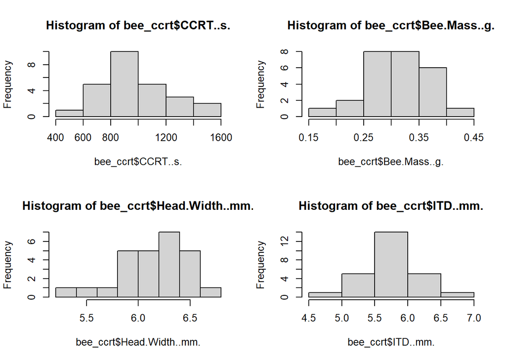

```r
#Exploratory Data Analysis
# Cleaning data
# removing N/As
bee_ccrt<- ccrt %>% # create new clean dataframe
  filter(!is.na(`CCRT..s.`), !is.na(`Bee.Mass..g.`), !is.na(`Wing.Wear.Left.Wing`), !is.na(`Wing.Wear.Right.Wing`), !is.na(`Head.Width..mm.`), !is.na(`Dufour.s.length..mm.`), !is.na(`Dufour.s.width..mm.`), !is.na(`Ovariole.1.length..mm.`), !is.na(`Ovariole.2.length..mm.`), !is.na(`Yellow.bodies.present.`))

# create bins for wing wear category
bee_ccrt<- bee_ccrt %>%
  mutate(wing_wear_left = case_when(`Wing.Wear.Left.Wing` == "0" ~ "undamaged",`Wing.Wear.Left.Wing` == "1" ~ "undamaged",`Wing.Wear.Left.Wing` == "2" ~ "damaged",`Wing.Wear.Left.Wing` == "3" ~ "damaged",`Wing.Wear.Left.Wing` == "4" ~ "damaged",`Wing.Wear.Left.Wing` == "5" ~ "damaged"),
    wing_wear_right = case_when(`Wing.Wear.Right.Wing` == "0" ~ "undamaged",`Wing.Wear.Right.Wing` == "1" ~ "undamaged",`Wing.Wear.Right.Wing` == "2" ~ "damaged",`Wing.Wear.Right.Wing` == "3" ~ "damaged",`Wing.Wear.Right.Wing` == "4" ~ "damaged",`Wing.Wear.Right.Wing` == "5" ~ "damaged"))


#check numeric variables for distributions and normality
## histograms
par(mfrow=c(2,2))
hist(bee_ccrt$CCRT..s.)
hist(bee_ccrt$Bee.Mass..g.)
hist(bee_ccrt$Head.Width..mm.)
hist(bee_ccrt$ITD..mm.)
```

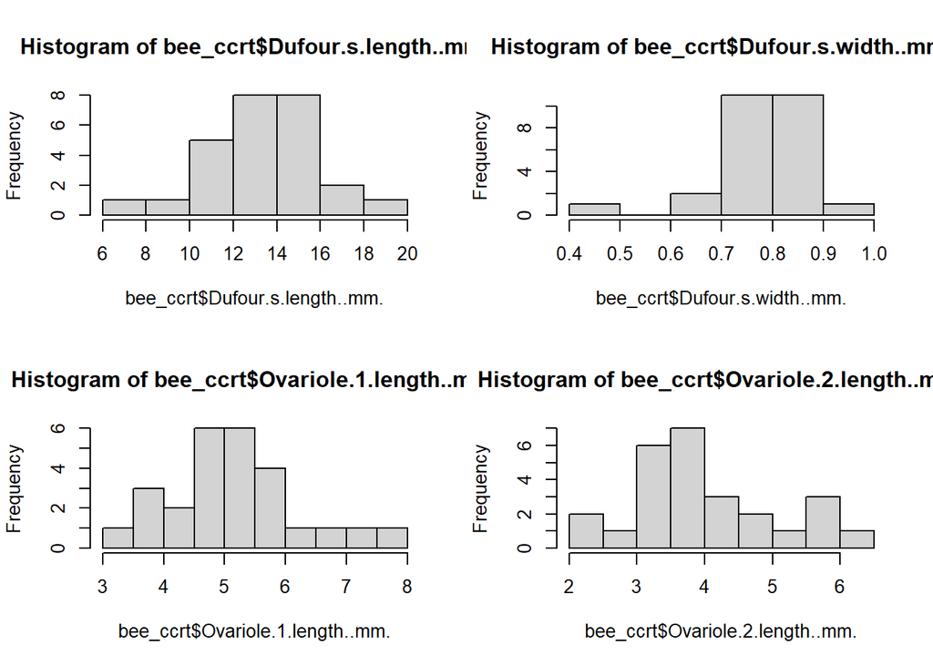

```r
hist(bee_ccrt$Dufour.s.length..mm.)
hist(bee_ccrt$Dufour.s.width..mm.)
hist(bee_ccrt$Ovariole.1.length..mm.)
hist(bee_ccrt$Ovariole.2.length..mm.)
```

```r
par(mfrow=c(1,1))
# everything looks pretty normal

## qqPlots
par(mfrow=c(2,2))
qqPlot(bee_ccrt$CCRT..s.)
```

```
## [1]  8 16
```

```r
qqPlot(bee_ccrt$Bee.Mass..g.)
```

```
## [1] 20 21
```

```r
qqPlot(bee_ccrt$Head.Width..mm.)
```

```
## [1] 20 24
```

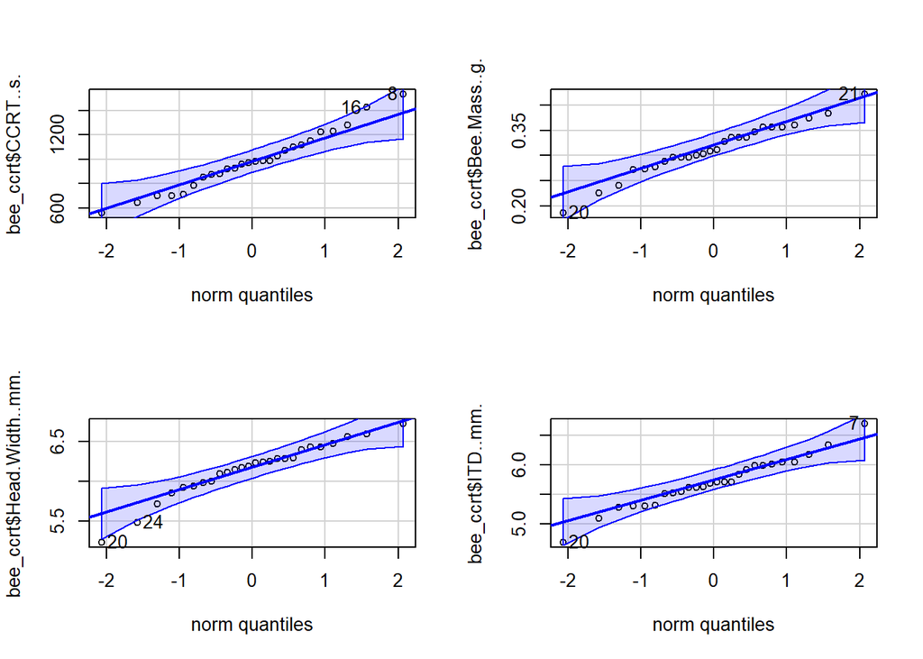

```
## [1] 20  7
```

```r
qqPlot(bee_ccrt$ITD..mm.)
```

```r
qqPlot(bee_ccrt$Dufour.s.length..mm.)
```

```
## [1]  8 25
```

```r
qqPlot(bee_ccrt$Dufour.s.width..mm.)
```

```
## [1] 18 22
```

```r
qqPlot(bee_ccrt$Ovariole.1.length..mm.)
```

```
## [1] 21  7
```

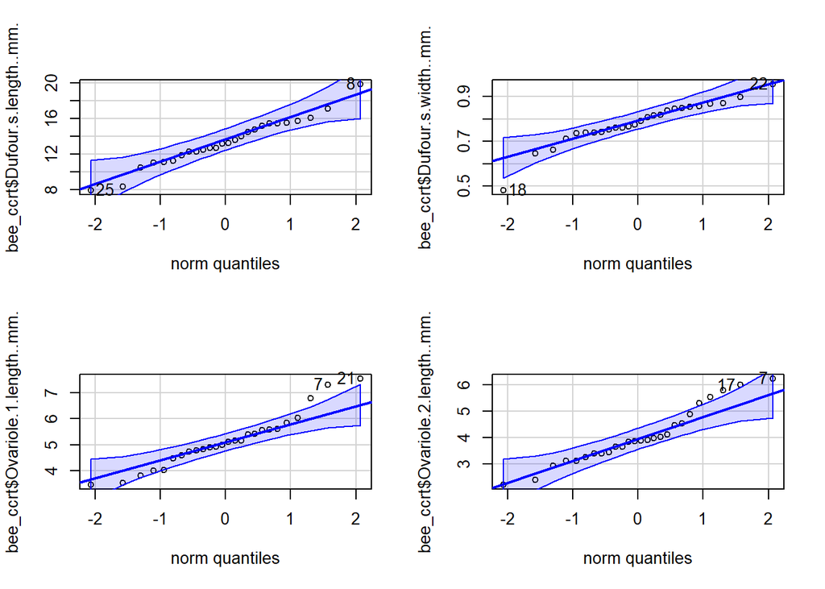

```
## [1]  7 17
```

```r
qqPlot(bee_ccrt$Ovariole.2.length..mm.)
```

```r
par(mfrow=c(1,1))
# normal normal normal

## shapiro tests
shapiro.test(bee_ccrt$CCRT..s.) # normal
```

```
##
##  Shapiro-Wilk normality test
##
## data:  bee_ccrt$CCRT..s.
## W = 0.98002, p-value = 0.8742
```

```r
shapiro.test(bee_ccrt$Bee.Mass..g.) # normal
```

```
##
##  Shapiro-Wilk normality test
##
## data:  bee_ccrt$Bee.Mass..g.
## W = 0.97993, p-value = 0.8725
```

```r
shapiro.test(bee_ccrt$Head.Width..mm.) # normal
```

```
##
##  Shapiro-Wilk normality test
##
## data:  bee_ccrt$Head.Width..mm.
## W = 0.94904, p-value = 0.2201
```

```r
shapiro.test(bee_ccrt$ITD..mm.) # normal
```

```
##
##  Shapiro-Wilk normality test
##
## data:  bee_ccrt$ITD..mm.
## W = 0.9806, p-value = 0.8865
```

```r
shapiro.test(bee_ccrt$Dufour.s.length..mm.) # normal
```

```
##
##  Shapiro-Wilk normality test
##
## data:  bee_ccrt$Dufour.s.length..mm.
## W = 0.97943, p-value = 0.8616
```

```r
shapiro.test(bee_ccrt$Dufour.s.width..mm.) # normal
```

```
##
##  Shapiro-Wilk normality test
##
## data:  bee_ccrt$Dufour.s.width..mm.
## W = 0.92288, p-value = 0.05255
```

```r
shapiro.test(bee_ccrt$Ovariole.1.length..mm.) # normal
```

```
##
##  Shapiro-Wilk normality test
##
## data:  bee_ccrt$Ovariole.1.length..mm.
## W = 0.94937, p-value = 0.2242
```

```r
shapiro.test(bee_ccrt$Ovariole.2.length..mm.) # normal
```

```
##
##  Shapiro-Wilk normality test
##
## data:  bee_ccrt$Ovariole.2.length..mm.
## W = 0.94788, p-value = 0.2068
```

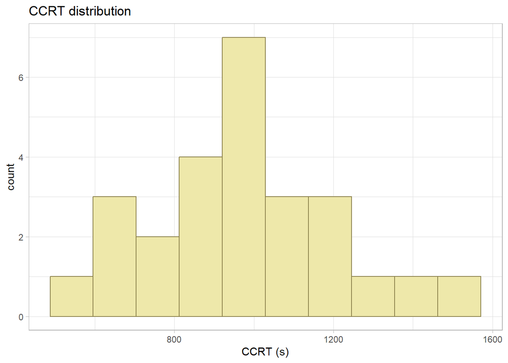

```r
# yay everything is normal and does not need transformation (all have p> 0.05)

#I am going to make a  beautiful plot of my y variable distribution for the report (Normal/ Gaussian distribution)
bee_ccrt %>% # pipe in cleaned data
  ggplot(aes(x= `CCRT..s.`)) + # using CCRT as y
  geom_histogram(color = "lightgoldenrod4", fill = "palegoldenrod", bins = 10) +
theme_light() + # change theme
  labs(x= "CCRT (s)", y = "count") + # add labels
  ggtitle("CCRT distribution") # add title
```

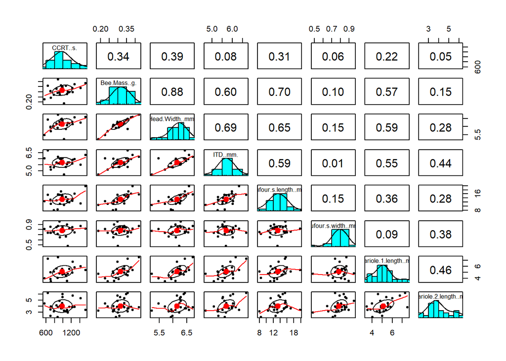

```r
# Comparing CCRT to X variables

 # numeric (pairs panels) to look for interesting themes
numerics <- bee_ccrt[,c("CCRT..s.", "Bee.Mass..g.", "Head.Width..mm.", "ITD..mm.", "Dufour.s.length..mm.", "Dufour.s.width..mm.", "Ovariole.1.length..mm.", "Ovariole.2.length..mm.")]
pairs.panels(numerics) #include as a fig
```

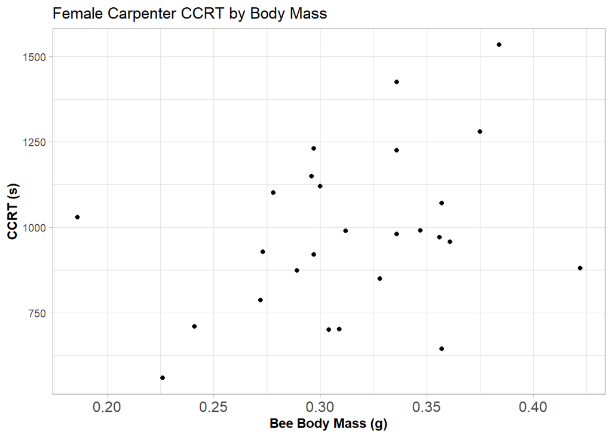

```r
# Mass vs. CCRT looks interesting and I would like to see if there is a correlation. The correlation scores between mass, head width, and ITD vs Dufour's length and Ovariole 1 length are all high. I want to test this aspect to see if bee size is a significant contributor to ovariole and Dufour's size rather than sociality.

# create a plot of Mass vs CCRT
bee_ccrt %>%
  ggplot(aes(y = CCRT..s., x = Bee.Mass..g.)) +
  geom_point(color = "black") +
  theme_light() +
  theme(axis.title = element_text(face = "bold"),
        axis.text.x = element_text(size = 12)) +
  labs(x = "Bee Body Mass (g)", y = "CCRT (s)") +
  ggtitle("Female Carpenter CCRT by Body Mass")
```

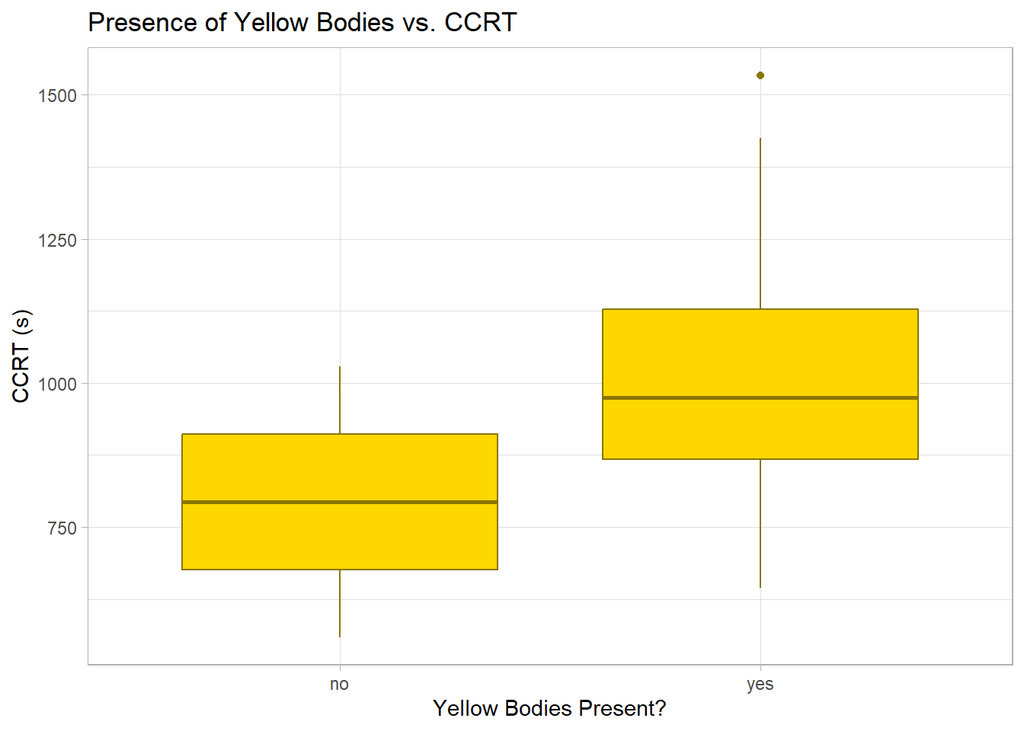

```r
# look at CCRT for yellow body groups and wing wear as indicators of age
bee_ccrt %>%
  ggplot(aes(x= `Yellow.bodies.present.`, y= `CCRT..s.`)) + # using yellow bodies and ccrt
  geom_boxplot(color = "gold4", fill = "gold") + # create a boxplot
  theme_light() + #make background white with grid marks
  labs(x= "Yellow Bodies Present?", y = "CCRT (s)") + # add appropriate labels
  ggtitle("Presence of Yellow Bodies vs. CCRT") # add a plot title))
```

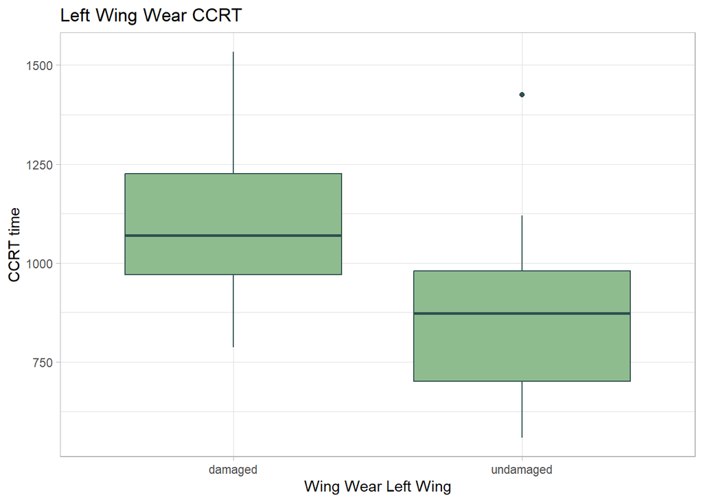

```r
bee_ccrt %>%
  ggplot(aes(x= `wing_wear_left`, y= `CCRT..s.`)) + # using left wing wear and ccrt
  geom_boxplot(color = "darkslategray", fill = "darkseagreen") + # create a boxplot
  theme_light() + #change theme
  labs(x= "Wing Wear Left Wing", y = "CCRT time") + # add appropriate labels
  ggtitle("Left Wing Wear CCRT") # add a plot title
```

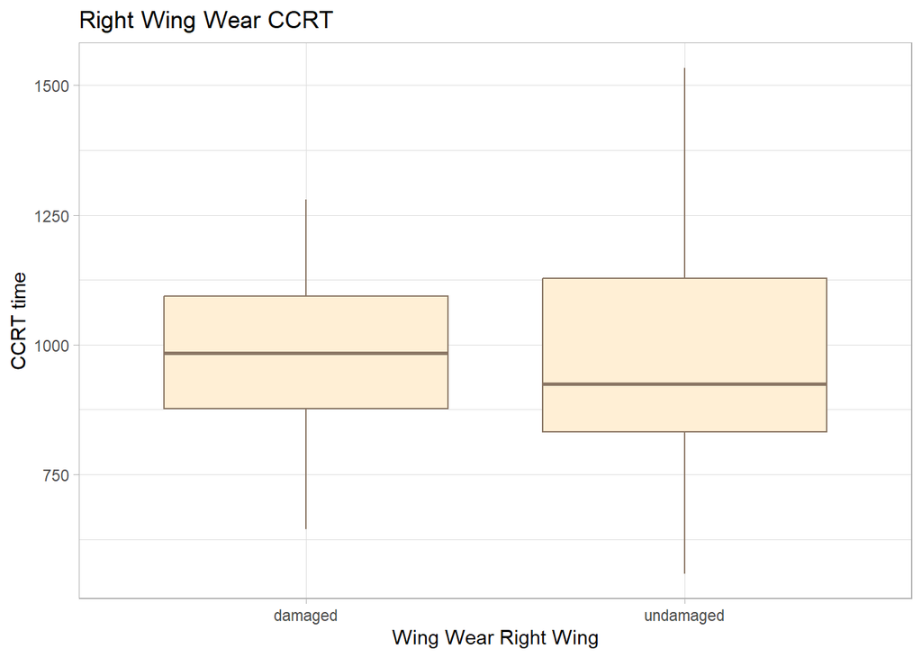

```r
bee_ccrt %>%
  ggplot(aes(x= `wing_wear_right`, y= `CCRT..s.`)) + # using left wing wear and ccrt
  geom_boxplot(color = "peachpuff4", fill = "papayawhip") + # create a boxplot
  theme_light() + #change theme
  labs(x= "Wing Wear Right Wing", y = "CCRT time") + # add appropriate labels
  ggtitle("Right Wing Wear CCRT") # add a plot title
```

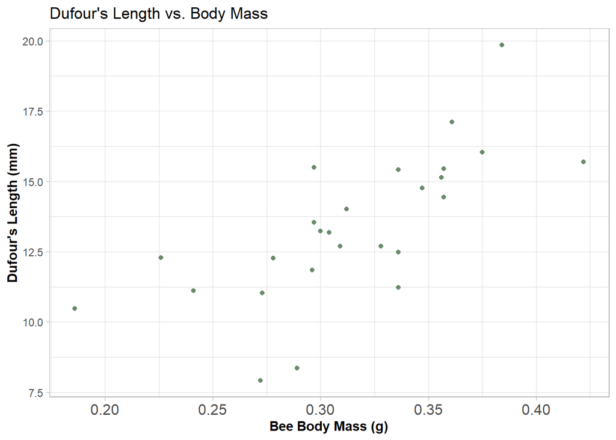

```r
bee_ccrt %>%
  ggplot(aes(y = Dufour.s.length..mm., x = Bee.Mass..g.)) +
  geom_point(color = "darkseagreen4") +
  theme_light() +
  theme(axis.title = element_text(face = "bold"),
        axis.text.x = element_text(size = 12)) +
  labs(x = "Bee Body Mass (g)", y = "Dufour's Length (mm)") +
  ggtitle("Dufour's Length vs. Body Mass")
```

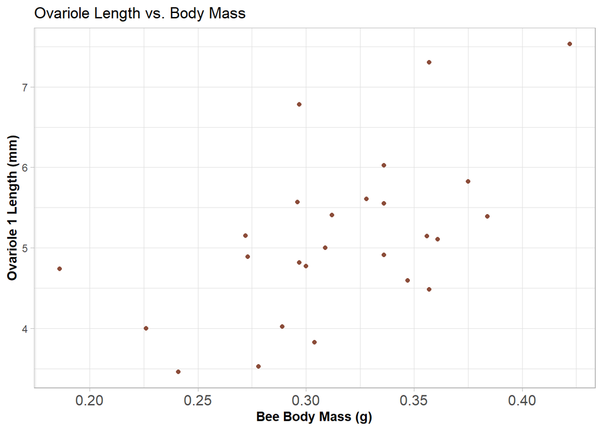

```r
bee_ccrt %>%
  ggplot(aes(y = Ovariole.1.length..mm., x = Bee.Mass..g.)) +
  geom_point(color = "salmon4") +
  theme_light() +
  theme(axis.title = element_text(face = "bold"),
        axis.text.x = element_text(size = 12)) +
  labs(x = "Bee Body Mass (g)", y = "Ovariole 1 Length (mm)") +
  ggtitle("Ovariole Length vs. Body Mass")
```

```r
#Findings:

# y~x numerical:

# All numeric values are normally distributed, the most interesting relationships I want to test are between CCRT and bee mass, and also bee mass and Dufour's and ovariole length.

# looking at the pairs panels for CCRT vs mass, the scatter plot suggests a positive relationship. The correlation coefficient is relatively low (0.34). Is this a significant predictor of CCRT?

# Looking between the x variables, we can see based on correlation coefficients that body measurements such as mass, head width, and ITD have a stronger positive linear relationship. These body size predictors are also associated more strongly with Dufour's length and ovariole length. Maybe additional statistical tests to help preliminary chemical analyses for Dufour's and Ovariole as a function of mass?

# y~x categorical:

# Based on the box plot, it seems that bees with yellow bodies present might have longer mean chill coma recovery time. Looking at wing wear, there seems to be an interesting discrepancy between left and right wing damage.

# Is there a significant difference between CCRT in bees with no yellow bodies (likely younger bees) versus bees with yellow bodies (post-reproductive)? Is there a significant difference between damaged and undamaged bees?

#I will run a two sample t test on my yellow bodies data to see if there is a significant difference between the means of CCRT between the two groups. I will run two seperate two sample t-tests to discern if there is a trend in CCRT between left and right wing damage.
```

### Section 2: Statistical methods

#### Two Sample T

```r
# goal: see if there is a difference in mean CCRT between bees with yellow bodies and bees without them
#run a two sample t-test on yellow body data

#check assumptions
#independent data? yes
#random? yes
#normality- Shapiro
#variance- Levene's

# create two data frames present and not present
YB_present <- bee_ccrt %>%
 filter(Yellow.bodies.present. == "yes")

no_YB <- bee_ccrt %>%
  filter(Yellow.bodies.present. == "no") # only 3 observations in this data frame, 1 missing CCRT, so not enough data for statistical comparison.

# Now looking at wing wear scores
# goal: see if there is a difference in mean CCRT between undamaged and damaged winged bees
#checking assumptions of 2 sample T for CCRT versus wing wear in left and right

#create new data frames for left and right wing with CCRT data
left_wing <- bee_ccrt %>%
dplyr:: select(CCRT..s., wing_wear_left)
right_wing <- bee_ccrt %>%
dplyr:: select(CCRT..s., wing_wear_right)

#check normality of subset data
shapiro.test(left_wing$CCRT..s.)
```

```
##
##  Shapiro-Wilk normality test
##
## data:  left_wing$CCRT..s.
## W = 0.98002, p-value = 0.8742
```

```r
shapiro.test(right_wing$CCRT..s.)
```

```
##
##  Shapiro-Wilk normality test
##
## data:  right_wing$CCRT..s.
## W = 0.98002, p-value = 0.8742
```

```r
# both normal

# check variance
# Run Levene's test for wing_wear_left
levene_left <- leveneTest(CCRT..s. ~ wing_wear_left, data = left_wing)
print(levene_left) #variance is equal (p > 0.05)
```

```
## Levene's Test for Homogeneity of Variance (center = median)
##       Df F value Pr(>F)
## group  1  0.1724 0.6817
##       24
```

```r
# Run Levene's test for wing_wear_right
levene_right <- leveneTest(CCRT..s. ~ wing_wear_right, data = right_wing)
print(levene_right) # variances are equal (p >0.05)
```

```
## Levene's Test for Homogeneity of Variance (center = median)
##       Df F value Pr(>F)
## group  1  1.2141 0.2814
##       24
```

```r
# Perform two sample t-test between damaged and undamaged within each group

#creating new data frames for each treatment group
yes_left <- bee_ccrt %>%
  filter(wing_wear_left == "damaged")

no_left <- bee_ccrt %>%
  filter(wing_wear_left == "undamaged")

yes_right <- bee_ccrt %>%
  filter(wing_wear_right == "damaged")

no_right <- bee_ccrt %>%
  filter(wing_wear_right == "undamaged")

 #run t test
lefty <- t.test(yes_left$CCRT..s., no_left$CCRT..s., var.equal = TRUE) # p = 0.01275, reject null (H0 = true difference in means is 0), significant difference between CCRT in damaged and undamaged bees
tidy_lefty <- tidy(lefty)
kable(tidy_lefty)
```

| estimate | estimate1 | estimate2 | statistic | p.value | parameter | conf.low | conf.high | method | alternative |
| --- | --- | --- | --- | --- | --- | --- | --- | --- | --- |
| 222.8462 | 1096.077 | 873.2308 | 2.691514 | 0.0127522 | 24 | 51.96397 | 393.7283 | Two Sample t-test | two.sided |

```r
righty <- t.test(yes_right$CCRT..s., no_right$CCRT..s., var.equal = TRUE) # p= 0.9856, fail to reject null, not significant, no difference in CCRT between damaged and undamaged
tidy_righty <- tidy(righty)
kable(tidy_righty)
```

| estimate | estimate1 | estimate2 | statistic | p.value | parameter | conf.low | conf.high | method | alternative |
| --- | --- | --- | --- | --- | --- | --- | --- | --- | --- |
| -1.72619 | 983.8571 | 985.5833 | -0.0182186 | 0.9856151 | 24 | -197.278 | 193.8257 | Two Sample t-test | two.sided |

#### Linear regression

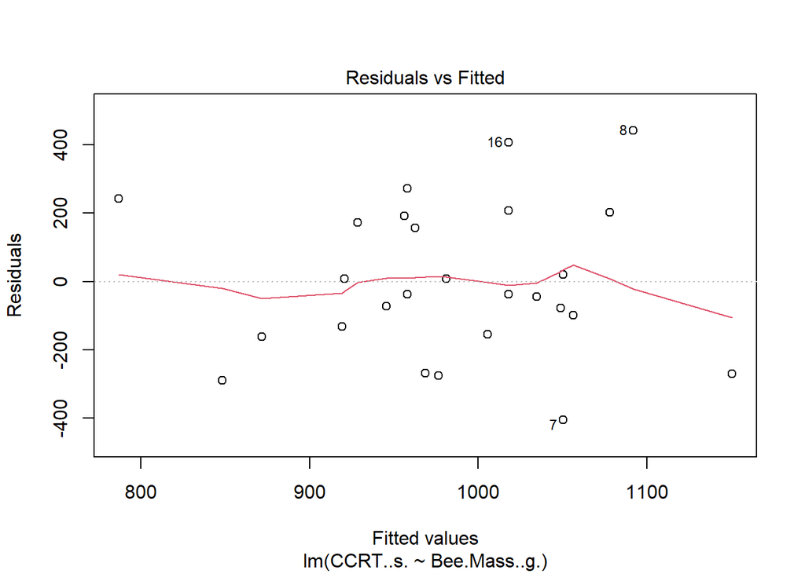

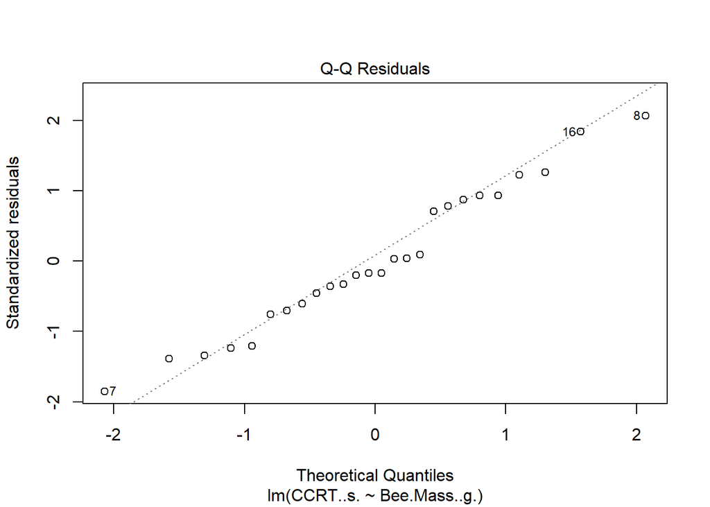

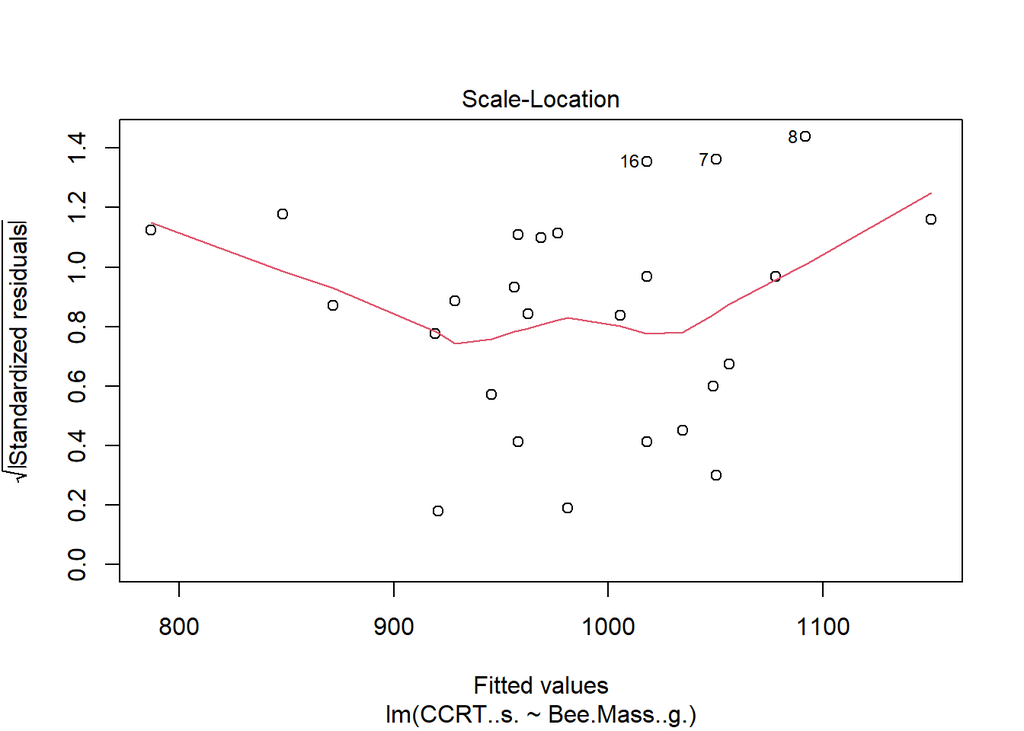

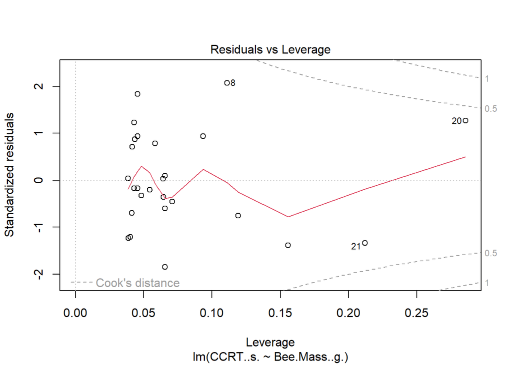

```r
# goal: see if CCRT can be predicted by body mass, and if ovariole length can be predicted by body mass

#check assumptions
#independent? yes
#normal residuals? yes (Shapiro Wilks p>0.05)
#equal variances? nope definitely not

massccrt <- lm(CCRT..s. ~ Bee.Mass..g., data = bee_ccrt)
plot(massccrt)
```

```r
residualsccrt <- residuals(massccrt)
shapiro.test(residualsccrt)
```

```
##
##  Shapiro-Wilk normality test
##
## data:  residualsccrt
## W = 0.96872, p-value = 0.5904
```

```r
# try a GLM for the special case of Gaussian distribution and display results
beeglm <- glm(CCRT..s. ~ Bee.Mass..g., data = bee_ccrt, family = "gaussian")
summary(beeglm)
```

```
##
## Call:
## glm(formula = CCRT..s. ~ Bee.Mass..g., family = "gaussian", data = bee_ccrt)
##
## Coefficients:
##              Estimate Std. Error t value Pr(>|t|)
## (Intercept)     500.2      279.5   1.790   0.0862 .
## Bee.Mass..g.   1540.8      877.7   1.756   0.0919 .
## ---
## Signif. codes:  0 '***' 0.001 '**' 0.01 '*' 0.05 '.' 0.1 ' ' 1
##
## (Dispersion parameter for gaussian family taken to be 51406.79)
##
##     Null deviance: 1392196  on 25  degrees of freedom
## Residual deviance: 1233763  on 24  degrees of freedom
## AIC: 359.74
##
## Number of Fisher Scoring iterations: 2
```

```r
tidy_beeglm <- tidy(beeglm)
kable(tidy_beeglm, caption = "Generalized Linear Model Results for Bee Mass vs. CCRT", col.names = c("Predictor", "Estimate SD", "SE", "t", "p-value"))
```

Generalized Linear Model Results for Bee Mass vs. CCRT

| Predictor | Estimate SD | SE | t | p-value |
| --- | --- | --- | --- | --- |
| (Intercept) | 500.2032 | 279.5136 | 1.789548 | 0.0861545 |
| Bee.Mass..g. | 1540.7605 | 877.6523 | 1.755548 | 0.0919232 |

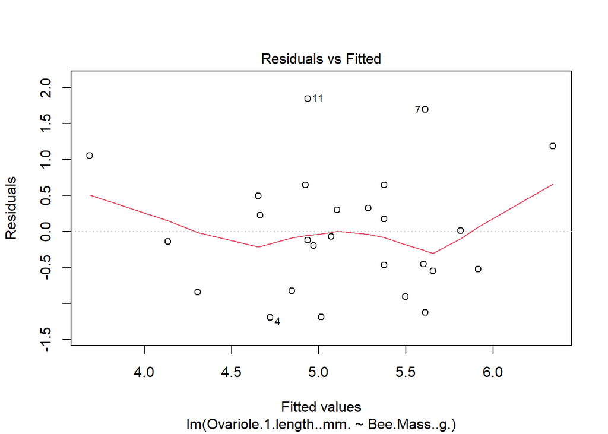

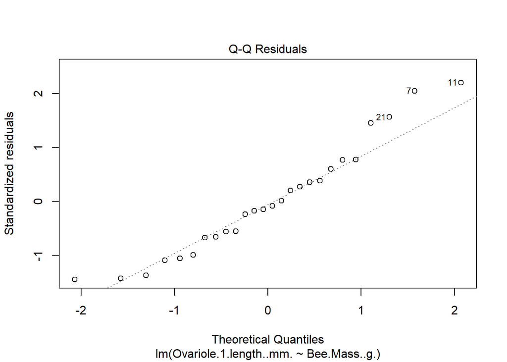

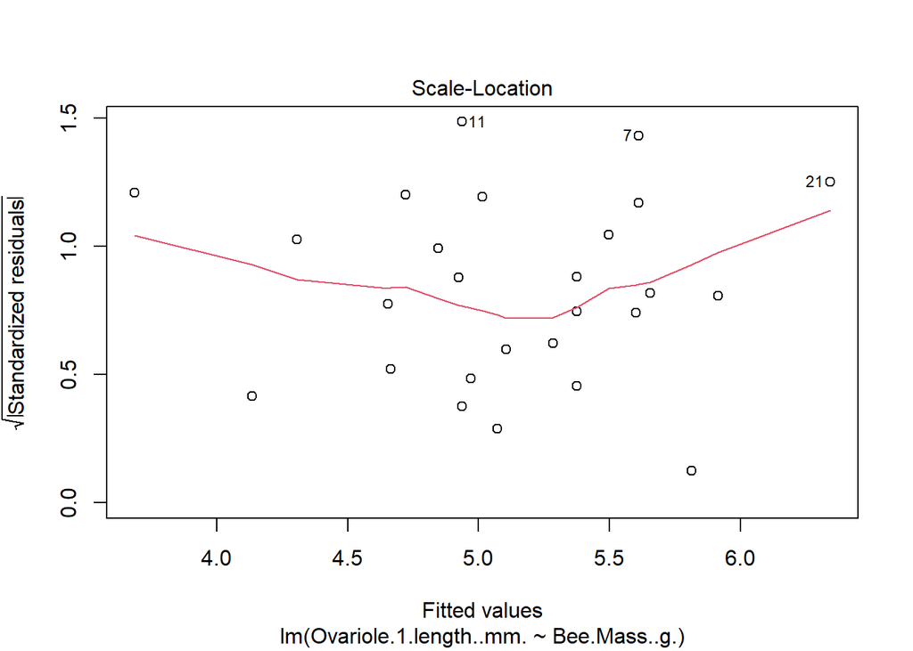

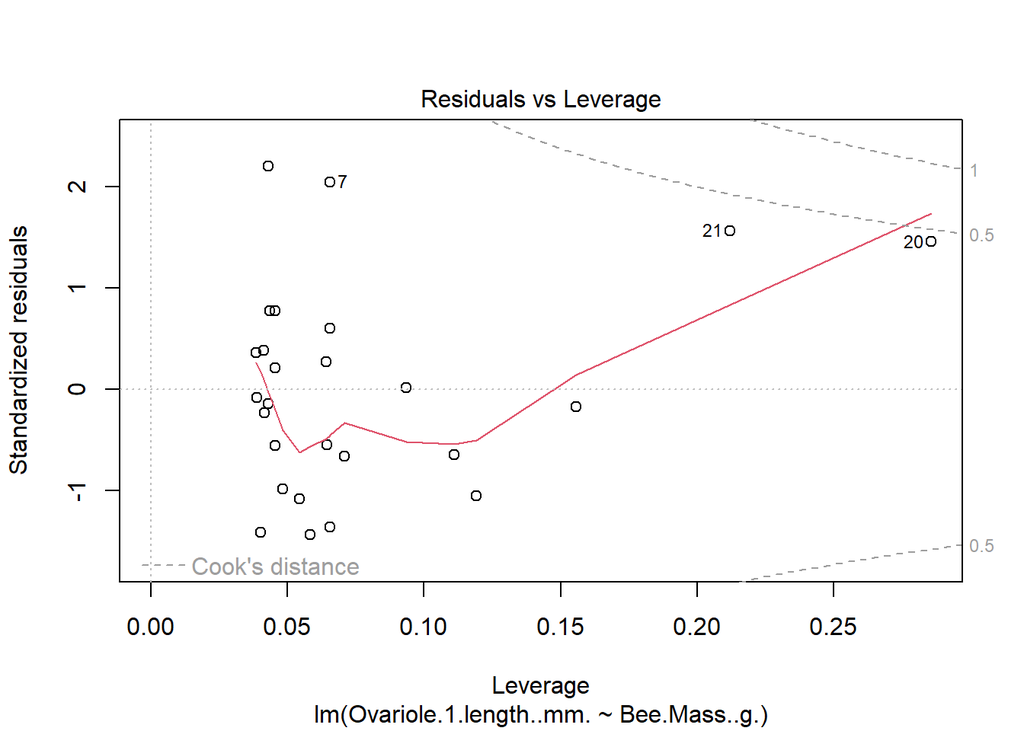

```r
# not a significant association between bee mass and ccrt

# try lm on ovariole data
#check assumptions of linear regression
#independent? yes
#normal residuals? yes (Shapiro test p> 0.05)
#equal variances? yes, fairly small deviation, residuals look homoscedastic

massov <- lm(Ovariole.1.length..mm. ~ Bee.Mass..g., data = bee_ccrt)
plot(massov)
```

```r
summary(massov)
```

```
##
## Call:
## lm(formula = Ovariole.1.length..mm. ~ Bee.Mass..g., data = bee_ccrt)
##
## Residuals:
##      Min       1Q   Median       3Q      Max
## -1.19798 -0.54323 -0.09446  0.45395  1.84510
##
## Coefficients:
##              Estimate Std. Error t value Pr(>|t|)
## (Intercept)     1.592      1.055   1.509  0.14423
## Bee.Mass..g.   11.259      3.311   3.400  0.00236 **
## ---
## Signif. codes:  0 '***' 0.001 '**' 0.01 '*' 0.05 '.' 0.1 ' ' 1
##
## Residual standard error: 0.8555 on 24 degrees of freedom
## Multiple R-squared:  0.3251, Adjusted R-squared:  0.297
## F-statistic: 11.56 on 1 and 24 DF,  p-value: 0.002357
```

```r
tidy_massov <- tidy(massov)

# make column for rsq
mass_play <-as.data.frame(tidy_massov)
mass_play$rsq <- rep(c(""))
tbl1<- tidy_massov %>%
  mutate(adj_rsq = c("NA", "0.297"))
kable(tbl1, caption = "Summary of Mass vs. Ovariole Length Linear Model", col.names = c("Predictor", "Estimate SD", "SE", "t", "p-value", "Adjusted- rsq"))
```

Summary of Mass vs. Ovariole Length Linear Model

| Predictor | Estimate SD | SE | t | p-value | Adjusted- rsq |
| --- | --- | --- | --- | --- | --- |
| (Intercept) | 1.591941 | 1.05462 | 1.509493 | 0.1442269 | NA |
| Bee.Mass..g. | 11.259134 | 3.31143 | 3.400082 | 0.0023571 | 0.297 |

```r
# check normality of residuals- normal p = 0.3383
residualsov <- residuals(massov)
shapiro.test(residualsov)
```

```
##
##  Shapiro-Wilk normality test
##
## data:  residualsov
## W = 0.95714, p-value = 0.3383
```